# Chap3: Exercises - Q14

Sanjeev Gadre

August 1, 2018

Including the necessary libraries

```r
library(ISLR)
library(car)
library(tidyverse)
```

## Problem 14

# 14.a

```r
set.seed(1)
x1 = runif(100)
x2 = 0.5*x1+rnorm(100)/10
y = 2+2*x1+0.3*x2+rnorm(100)
```

This linear model is of the form Y= beta-0 + beta-1*X1 + beta_2*X2 + std. normal error and the regression coefficeints are beta-0 = 2, beta-1 = 2 and beta-2 = 0.3.

# 14.b

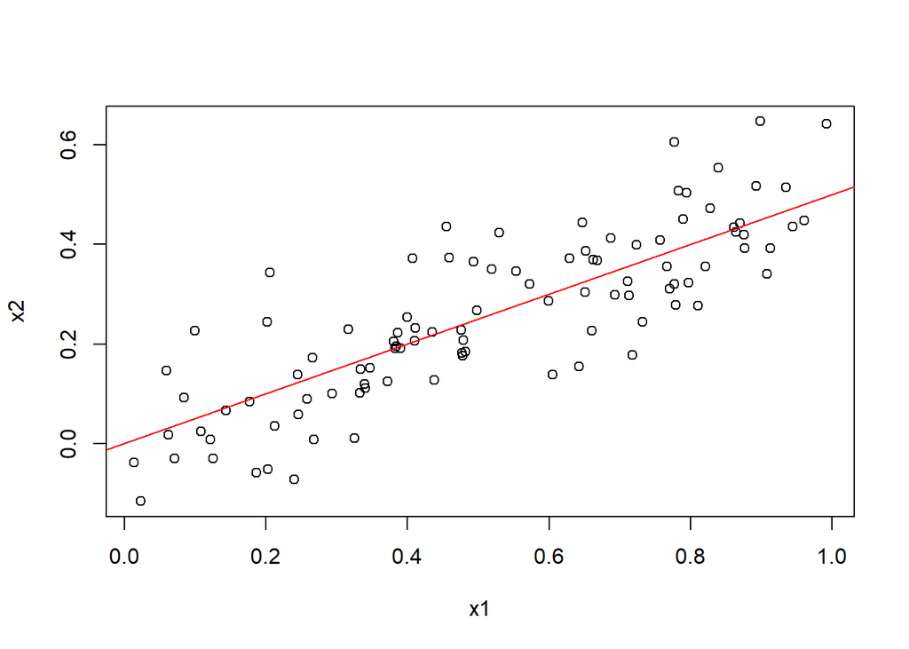

As the plot above shows, x2 is linearly related to the x1. This is to be expected as x2 is defined as linear function of x1

# 14.c

```r
linear_fit_1 = lm(y~x1+x2)
summary_1 = summary(linear_fit_1)
summary_1
```

```
##
## Call:
## lm(formula = y ~ x1 + x2)
##
## Residuals:
##     Min      1Q  Median      3Q     Max
## -2.8311 -0.7273 -0.0537  0.6338  2.3359
##
## Coefficients:
##             Estimate Std. Error t value Pr(>|t|)
## (Intercept)   2.1305     0.2319   9.188 7.61e-15 ***
## x1            1.4396     0.7212   1.996   0.0487 *
## x2            1.0097     1.1337   0.891   0.3754
## ---
## Signif. codes:  0 '***' 0.001 '**' 0.01 '*' 0.05 '.' 0.1 ' ' 1
##
## Residual standard error: 1.056 on 97 degrees of freedom
## Multiple R-squared:  0.2088, Adjusted R-squared:  0.1925
## F-statistic:  12.8 on 2 and 97 DF,  p-value: 1.164e-05
```

```
## [1] 0.375
```

*The R-squared value is quite low, indicating a poor fit*

```
## [1] 0.209
```

The three coefficients beta-hat-0, beta-hat-1 and beta-hat-2, respectively are

```
## [1] 2.1305
```

```
## [1] 1.439555
```

```
## [1] 1.009674
```

Clearly only beta_hat_0 compares well with beta_0. beta_hat_1 is somewhat comparable to beta_1 but beta_hat_2 is way off beta_2

However, the *F-statistic for the overall fit has a low p-value*, indicating that the hypothesis that x1 and/or x2 are predictors of y may not be dismissed, though from the summary results its clear that for **this** fit x2 is not a good predictor of y.

# 14.d

```r
linear_fit_2 = lm(y~x1)
summary_2 = summary(linear_fit_2)
summary_2
```

```
##
## Call:
## lm(formula = y ~ x1)
##
## Residuals:
##      Min       1Q   Median       3Q      Max
## -2.89495 -0.66874 -0.07785  0.59221  2.45560
##
## Coefficients:
##             Estimate Std. Error t value Pr(>|t|)
## (Intercept)   2.1124     0.2307   9.155 8.27e-15 ***
## x1            1.9759     0.3963   4.986 2.66e-06 ***
## ---
## Signif. codes:  0 '***' 0.001 '**' 0.01 '*' 0.05 '.' 0.1 ' ' 1
##
## Residual standard error: 1.055 on 98 degrees of freedom
## Multiple R-squared:  0.2024, Adjusted R-squared:  0.1942
## F-statistic: 24.86 on 1 and 98 DF,  p-value: 2.661e-06
```

The summary results for y~x1 fit indicate: *x1 is a strong predictor of y because of its low p-value of*

```
## [1] 2.66e-06
```

*The fit quality is not very good given a low R-squared value of*

```
## [1] 0.2023601
```

# 14.e

```r
linear_fit_3 = lm(y~x2)
summary_3 = summary(linear_fit_3)
summary_3
```

```
##
## Call:
## lm(formula = y ~ x2)
##
## Residuals:
##      Min       1Q   Median       3Q      Max
## -2.62687 -0.75156 -0.03598  0.72383  2.44890
##
## Coefficients:
##             Estimate Std. Error t value Pr(>|t|)
## (Intercept)   2.3899     0.1949   12.26  < 2e-16 ***
## x2            2.8996     0.6330    4.58 1.37e-05 ***
## ---
## Signif. codes:  0 '***' 0.001 '**' 0.01 '*' 0.05 '.' 0.1 ' ' 1
##
## Residual standard error: 1.072 on 98 degrees of freedom
## Multiple R-squared:  0.1763, Adjusted R-squared:  0.1679
## F-statistic: 20.98 on 1 and 98 DF,  p-value: 1.366e-05
```

The summary results for y~x2 fit indicate: *x2 is a strong predictor of y because of its low p-value of*

```
## [1] 1.37e-05
```

*The fit quality is not very good given a low R-squared value of*

```
## [1] 0.1763304
```

# 14.f

```r
cor(x1,x2)
```

```
## [1] 0.8351212
```

# 14.g

```r
x1 = c(x1, 0.1)
x2 = c(x2, 0.8)
y = c(y, 6)

linear_fit_1a = lm(y~x1+x2)
summary_1a = summary(linear_fit_1a)
summary_1a
```

```
##
## Call:
## lm(formula = y ~ x1 + x2)
##
## Residuals:
##      Min       1Q   Median       3Q      Max
## -2.73348 -0.69318 -0.05263  0.66385  2.30619
##
## Coefficients:
##             Estimate Std. Error t value Pr(>|t|)
## (Intercept)   2.2267     0.2314   9.624 7.91e-16 ***
## x1            0.5394     0.5922   0.911  0.36458
## x2            2.5146     0.8977   2.801  0.00614 **
## ---
## Signif. codes:  0 '***' 0.001 '**' 0.01 '*' 0.05 '.' 0.1 ' ' 1
##
## Residual standard error: 1.075 on 98 degrees of freedom
## Multiple R-squared:  0.2188, Adjusted R-squared:  0.2029
## F-statistic: 13.72 on 2 and 98 DF,  p-value: 5.564e-06
```

```r
linear_fit_2a = lm(y~x1)
summary_2a = summary(linear_fit_2a)
summary_2a
```

```
##
## Call:
## lm(formula = y ~ x1)
##
## Residuals:
##     Min      1Q  Median      3Q     Max
## -2.8897 -0.6556 -0.0909  0.5682  3.5665
##
## Coefficients:
##             Estimate Std. Error t value Pr(>|t|)
## (Intercept)   2.2569     0.2390   9.445 1.78e-15 ***
## x1            1.7657     0.4124   4.282 4.29e-05 ***
## ---
## Signif. codes:  0 '***' 0.001 '**' 0.01 '*' 0.05 '.' 0.1 ' ' 1
##
## Residual standard error: 1.111 on 99 degrees of freedom
## Multiple R-squared:  0.1562, Adjusted R-squared:  0.1477
## F-statistic: 18.33 on 1 and 99 DF,  p-value: 4.295e-05
```

```r
linear_fit_3a = lm(y~x2)
summary_3a = summary(linear_fit_3a)
summary_3a
```

```
##
## Call:
## lm(formula = y ~ x2)
##
## Residuals:
##      Min       1Q   Median       3Q      Max
## -2.64729 -0.71021 -0.06899  0.72699  2.38074
##
## Coefficients:
##             Estimate Std. Error t value Pr(>|t|)
## (Intercept)   2.3451     0.1912  12.264  < 2e-16 ***
## x2            3.1190     0.6040   5.164 1.25e-06 ***
## ---
## Signif. codes:  0 '***' 0.001 '**' 0.01 '*' 0.05 '.' 0.1 ' ' 1
##
## Residual standard error: 1.074 on 99 degrees of freedom
## Multiple R-squared:  0.2122, Adjusted R-squared:  0.2042
## F-statistic: 26.66 on 1 and 99 DF,  p-value: 1.253e-06
```

Comparing the 3 models with respective updated models:

```
## [1] "y~x1+x2"
```

```
##          R_squared   beta_0    beta_1   beta_2
## Original 0.2088293 2.130500 1.4395554 1.009674
## Updated  0.2187973 2.226692 0.5394397 2.514569
```

```
## [1] "y~x1"
```

```
##          R_squared   beta_0   beta_1
## Original 0.2023601 2.112394 1.975929
## Updated  0.1562497 2.256927 1.765695
```

```
## [1] "y~x2"
```

```
##          R_squared   beta_0   beta_1
## Original 0.1763304 2.389949 2.899585
## Updated  0.2121829 2.345107 3.119050
```